## Report: act_report

- Create a **250-word-minimum written report** called "act_report.pdf" or "act_report.html" that communicates the insights and displays the visualization(s) produced from your wrangled data. This is to be framed as an external document, like a blog post or magazine article, for example.

# Introduction

Below is a report showing an analysis of a WeRateDogs dataset gathered using Twitter API, neural network image recognitions from Udacity, and Twitter archives from Udacity. I gathered the data from various sources, analysed it and cleaned it. During this process, I noticed some insights and decided to further investigate. I conducted investigations on the correlation between year, retweet count and favourite count, the dog which is most identified and I also took some insights on what hour the admin tweets the most.

```python
#Viewing the mean retweet count for every year in the dataframe
df.groupby(df.timestamp.map(lambda x: x.year)).mean()[["retweet_count", "favorite_count"]]
```

| timestamp | retweet_count | favorite_count |
| --- | --- | --- |
| 2015 | 1100.390988 | 2526.401163 |
| 2016 | 2756.590993 | 7601.662684 |
| 2017 | 5620.005013 | 22591.045113 |

```python
#View the dog with a p1_conf greater than 0.7 that was most recognized the most by the neural network
df[(df.p1_conf >0.7) & (df.p1_dog == True)].groupby('p1').count().sort_values('p1_conf', ascending = False).head(1)['p1_conf']
```

```
p1
golden retriever    85
Name: p1_conf, dtype: int64
```

```python
#View the hour that the dog_rates admin tweeted the most
df.groupby(df.timestamp.map(lambda x: x.hour)).count()["tweet_id"]
```

```
timestamp
0     268
1     296
2     226
3     187
4     107
5      29
6       5
12      2
13      3
14      9
15     97
16    208
17    175
18    112
19     94
20     87
21     78
22     75
23    117
Name: tweet_id, dtype: int64
```

### Insights:

1. As the years progress, the mean retweet counts and favorite counts have increased
2. Golden Retriver is the dog with a p1_conf greater than 0.7 that was recognized the most by the neural network
3. We can see the admin mostly tweets between 11pm to 4am

### Visualization

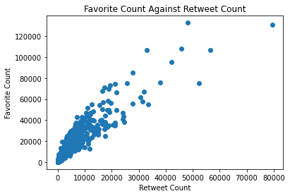

```python
#Visualizing the correlation between retweet_count and favorite_count
plt.scatter(df['retweet_count'], df['favorite_count'])
plt.title('Favorite Count Against Retweet Count')
plt.ylabel("Favorite Count")
plt.xlabel('Retweet Count');
```

# Report

From the first insight, we can see that the average retweet count and favourite count for each year have seen an increase from the previous year. This shows that the Twitter account has seen growth in either followers or viewer reach over the years. This also shows that the account had an increase in interactions over time. If we were to create a plot for this we would see a positive correlation.

The golden retriever is the dog that has been recognized the most by the neural network, I purposely selected the results from p1 with a confidence greater than 0.7in order to get results would be as close to accurate as possible.